# SF Crime Report Summer 2014

## Overview Of The Dataset

Incidents derived from SFPD Crime Incident Reporting system Updated daily, showing data from 1/1/2003 up until two weeks ago from current date. Please note: San Francisco police have implemented a new system for tracking crime. The dataset included here is still coming from the old system, which is in the process of being retired (a multi-year process). Data included here is no longer the official SFPD data. We will migrate to the new system for DataSF in the upcoming months.

In this report we analyze the incidents pertaining only to the incidents pertaining to summer 2014. We answer the following questions in this visualisation:

- What are the major categories of crimes committeed?
- during which part of the day were the crimes committed the most ?
- What crime category was committed the most during borad daylight ?
- Which area contributed the most to these crimes ?

## Summary of the dataset

```
##    IncidntNum                  Category
##  Min.   : 10284385   LARCENY/THEFT :9466
##  1st Qu.:140545607   OTHER OFFENSES:3567
##  Median :140632022   NON-CRIMINAL  :3023
##  Mean   :142017280   ASSAULT       :2882
##  3rd Qu.:140719664   VEHICLE THEFT :1966
##  Max.   :990367398   WARRANTS      :1782
##                      (Other)       :6307
##                          Descript         DayOfWeek            Date
##  GRAND THEFT FROM LOCKED AUTO: 3766   Friday   :4451   06/28/2014:  410
##  STOLEN AUTOMOBILE           : 1350   Monday   :4005   08/09/2014:  410
##  LOST PROPERTY               : 1202   Saturday :4319   08/08/2014:  403
##  PETTY THEFT OF PROPERTY     : 1125   Sunday   :4218   06/29/2014:  397
##  WARRANT ARREST              :  980   Thursday :3968   08/29/2014:  388
##  PETTY THEFT FROM LOCKED AUTO:  955   Tuesday  :3930   06/04/2014:  380
##  (Other)                     :19615   Wednesday:4102   (Other)   :26605
##       Time           PdDistrict             Resolution
##  12:00  :  784   SOUTHERN :5739   NONE           :19139
##  00:01  :  661   MISSION  :3700   ARREST, BOOKED : 6502
##  18:00  :  649   NORTHERN :3589   ARREST, CITED  : 1419
##  19:00  :  621   CENTRAL  :3513   LOCATED        : 1042
##  17:00  :  594   BAYVIEW  :2725   UNFOUNDED      :  260
##  20:00  :  586   INGLESIDE:2378   JUVENILE BOOKED:  163
##  (Other):25098   (Other)  :7349   (Other)        :  468
##                      Address            X                Y
##  800 Block of BRYANT ST  :  948   Min.   :-122.5   Min.   :37.71
##  800 Block of MARKET ST  :  288   1st Qu.:-122.4   1st Qu.:37.76
##  900 Block of POTRERO AV :  230   Median :-122.4   Median :37.78
##  1000 Block of POTRERO AV:  199   Mean   :-122.4   Mean   :37.77
##  2000 Block of MISSION ST:  149   3rd Qu.:-122.4   3rd Qu.:37.79
##  16TH ST / MISSION ST    :  116   Max.   :-122.4   Max.   :37.82
##  (Other)                 :27063
##                                   Location          PdId
##  (37.775420706711, -122.403404791479) :  940   Min.   :1.028e+12
##  (37.7571580431915, -122.406604919508):  224   1st Qu.:1.405e+13
##  (37.7564864109309, -122.406539115148):  196   Median :1.406e+13
##  (37.7650501214668, -122.419671780296):  152   Mean   :1.420e+13
##  (37.7841893501425, -122.407633520742):  150   3rd Qu.:1.407e+13
##  (37.7285280627465, -122.475647460786):  102   Max.   :9.904e+13
##  (Other)                              :27229
```

Let us look at the summary of the dataset. Here is a data cookbook exlaining what each label stands for:

- Dates - timestamp of the crime incident
- Category - category of the crime incident (only in train.csv). This is the target variable you are going to predict.
- Descript - detailed description of the crime incident (only in train.csv)
- DayOfWeek - the day of the week
- PdDistrict - name of the Police Department District
- Resolution - how the crime incident was resolved (only in train.csv)
- Address - the approximate street address of the crime incident
- X - Longitude
- Y - Latitude

## Intial exploration of incidents by different factors

First lets observe the incident count vs day of the week. This is to see if there is any particular trend pertaining to weekend vs number of crimes or not.

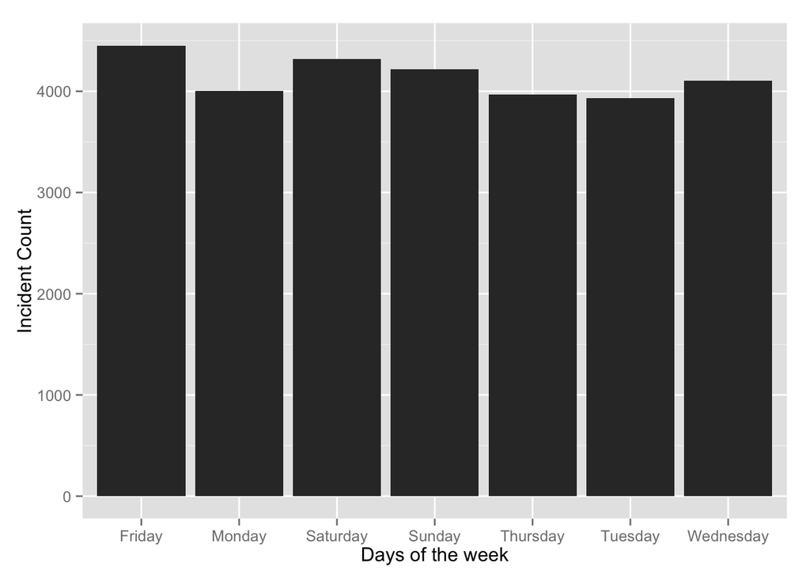

As seen from the above figure, there are no specific trend that can be seen easily. Let us drill down further to observe any other kind of connections between Incidents and other categorical variable.

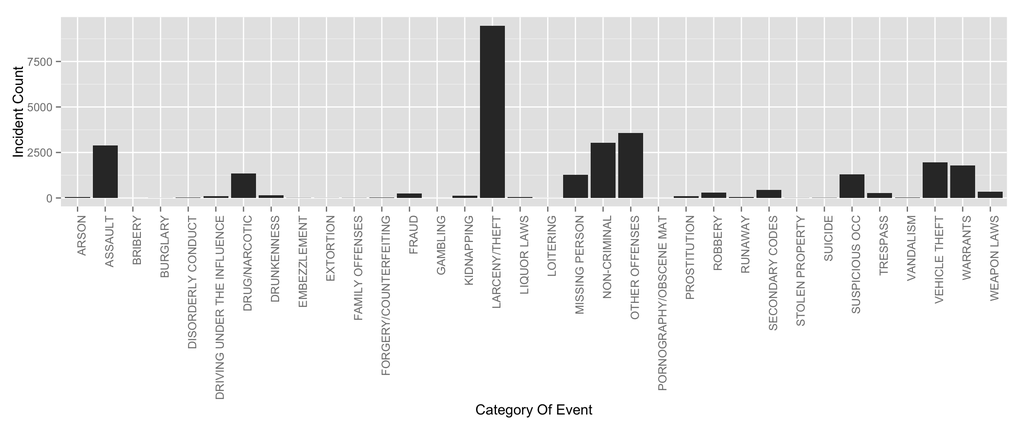

Over the course of summer 2014, the highest incident report pertains to larceny and theft. Let us have a look now at the distribution of crimes over the time of the day to find some kind of inference. It is expeected that most crimes occur either during late night.

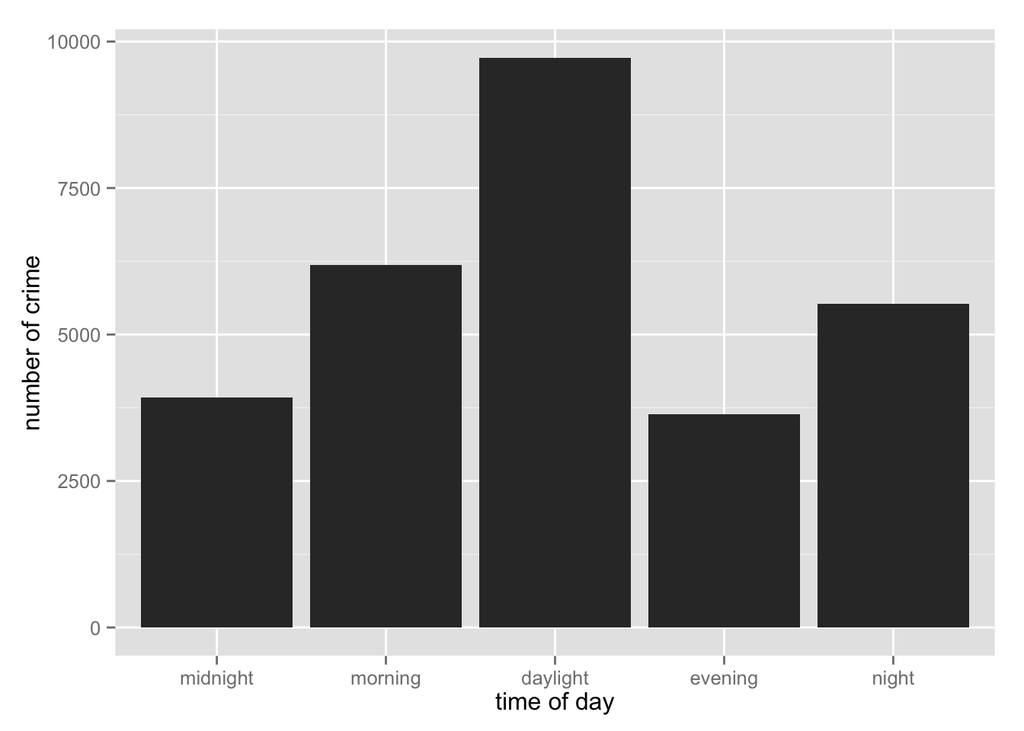

From the above graph, we find that the maximum crime occurs druing broad daylight. This is surprising and it would be even more interesting to see the crimes that have been commited during this time. One could not obviously expect crimes such as assault being committed in borad daylight. We would generally not expect theft to pop up in the results. Let us have a look to see in detail what are the crimes committed during borad daylight.

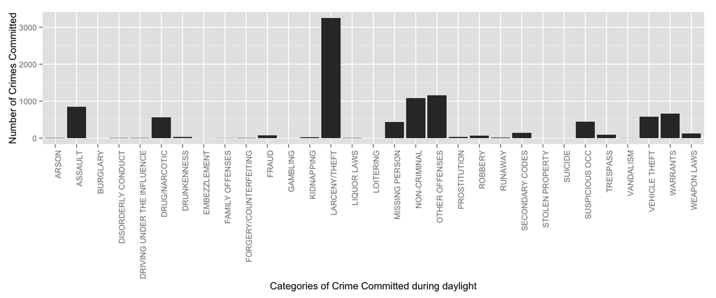

Which areas have been affected the most because of Larceny/Theft ?

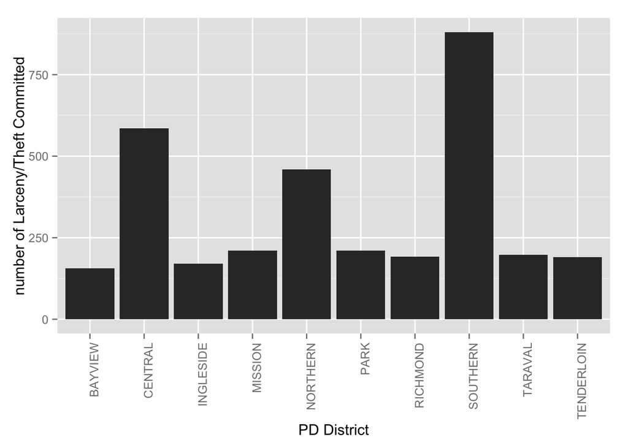

In order to validate the above graph, let us plot the map of San Francisco. Plotting the map, we see that the major crimes during daylight was committed in the area mentioned in the distribution above.

[figure not shown]